# Customer Clustering

Utkarsh Sharma

16/11/2019

## 1. Problem Statement, Dataset and Pre-processing

To handle the task of clustering customers, we are taking into account a fictitious database. Customers of the business are measured in the following criteria:

1. Demographics (Gender, Age, Annual Income)
2. Channels (Acquisition Source)
3. Engagement (Spending Score)

The Spending Score is a score on a scale of 1-100 which the business uses to rank its customers. A higher spending score means the customer engages more with the products of the business, and drives more profit than a customer with a lower spending score.

```r
# Importing the dataset
library(readxl)
dataset = read_excel("Customers.xlsx")
dataset = dataset[2:6]

head(dataset)
```

```
## # A tibble: 6 x 5
##   Gender   Age `Annual Income (k$… `Spending Score (1-1… `Acquisition Sour…
##   <chr>  <dbl>               <dbl>                 <dbl> <chr>
## 1 Female    35                  19                    99 Internet
## 2 Female    35                  23                    98 Internet
## 3 Male      28                  77                    97 Internet
## 4 Male      30                  99                    97 Agent
## 5 Female    33                  86                    95 Agent
## 6 Male      40                  71                    95 Internet
```

```r
# Encoding the categorical variables as factors
dataset$`Acquisition Source` = as.numeric(factor(dataset$`Acquisition Source`,
                                      levels = c('Internet', 'Agent'),
                                      labels = c(1, 2)))

dataset$Gender = as.numeric(factor(dataset$Gender,
                                   levels = c('Female', 'Male'),
                                   labels = c(1, 2)))
```

## 2. K-Means Clustering

To find the optimal number of disjoint clusters to divide the customers into, we use the Silhouette method.

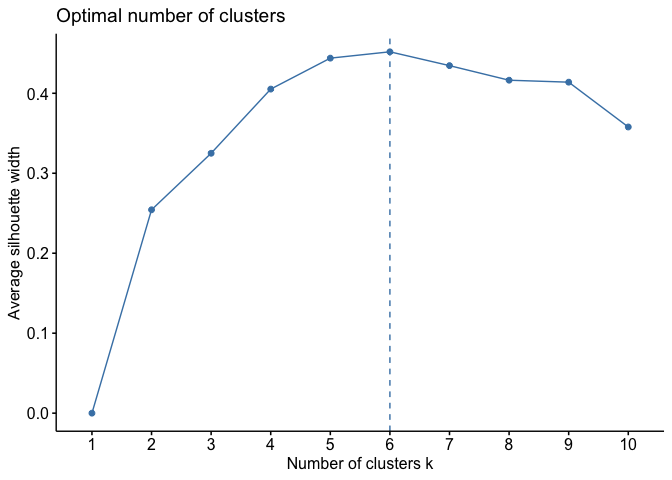

```r
# Optimal number of clusters
library(factoextra)
fviz_nbclust(dataset, kmeans, method='silhouette')
```

```r
set.seed(100)
kmeans = kmeans(x = dataset, centers = 6)
dataset$Cluster <- as.factor(kmeans$cluster)
```

## 3. Analysing Clusters

```r
library(dplyr)
cluster_analysis <- dataset %>% group_by(Cluster) %>% summarise(Count = n(),
                                                                MeanAnnualIncome = mean(`Annual Income (k$)`),
                                                                AverageAge = mean(Age),
                                                                AverageSpendingScore = mean(`Spending Score (1-100)`))

head(cluster_analysis)
```

```
## # A tibble: 6 x 5
##   Cluster Count MeanAnnualIncome AverageAge AverageSpendingScore
##   <fct>   <int>            <dbl>      <dbl>                <dbl>
## 1 1          52             54.4       53.7                 48.7
## 2 2          50             41.5       24.8                 63.7
## 3 3          38             87         40.4                 18.6
## 4 4          10            110.        32.2                 82
## 5 5          29             78.6       32.9                 82.2
## 6 6          21             25.1       44.1                 19.5
```

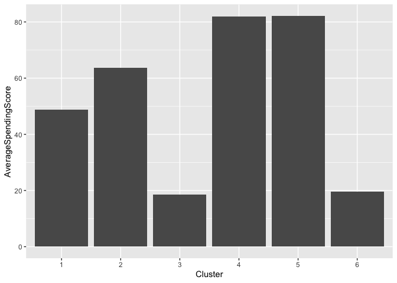

```r
# Visual Analysis
library(ggplot2)
ggplot(cluster_analysis, aes(Cluster, AverageSpendingScore)) + geom_col()
```

It can be seen that clusters 4 and 5 are the clusters with the highest mean Spending Score, followed by Cluster 2. To look into the demographics of these clusters further;

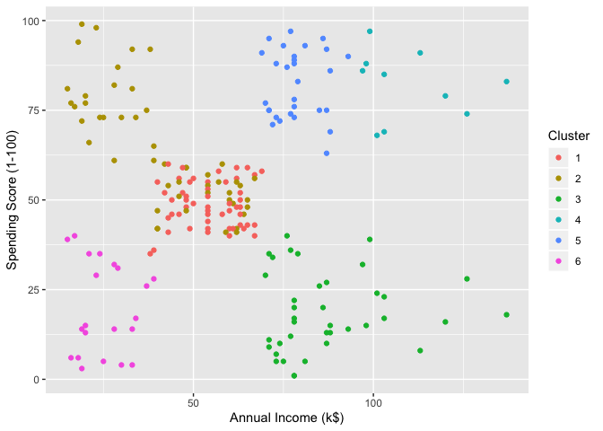

```r
ggplot(dataset, aes(`Annual Income (k$)`, `Spending Score (1-100)`, color = Cluster)) + geom_point()
```

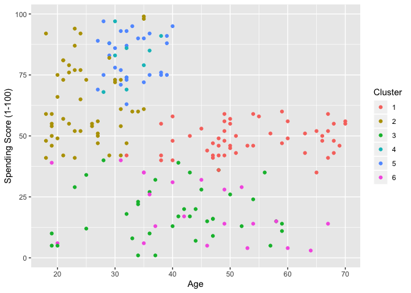

```r
ggplot(dataset, aes(Age, `Spending Score (1-100)`, color = Cluster)) + geom_point()
```

The clusters can be summarised as;

1. Cluster 1 - Customers with age greater than 30 and average annual income have an average Spending Score of about 50.
2. Cluster 2 - Young customers with low annual income have a higher than average Spending Score of about 63.
3. Cluster 3 - Customers with age less than 60 and a higher than average annual income have a very low average Spending Score.
4. Cluster 4 - People in their 30’s with very high annual income have a very high mean Spending Score.
5. Cluster 5 - People in their 30’s with higher than average annual income have the highest mean Spending Score.
6. Cluster 6 - People past their 40’s with very low annual income have a very low average Spending Score.

## 4. Results and Future Work

The customers are successfully divided into six disjoint groups, analysis of which can help the business drive strategy to target a particular customer group to increase profits. Furthermore, we can use Classification algorithms to assign future customers into relevant groups.